# ENV221 L10

Author

Peng Zhao

# 1 Overview of the module and R

# 2 R Basic Operations

# 3 R Programming

# 4 Statistical Graphs

# 5 Basic Concepts

# 6 Descriptive statistics

# 7 Distributions and the Central Limit Theorem

# 8 Hypothesis test

# 9 t-test

# 10 Numerical vs. Numerical

## 10.1 Learning objectives

In this lecture, you will

1. Explore a relationship between two numeric variables,
2. Work with regression,
3. Understand what correlation is all about,
4. Discover how correlation connects to regression, and
5. Visualize linear regression and correlations.

## 10.2 Regression

### 10.2.1 Prediction

Example: Predict the shoe size of an ENV221 student. What is the best prediction for a student I do not know?

- The mean.

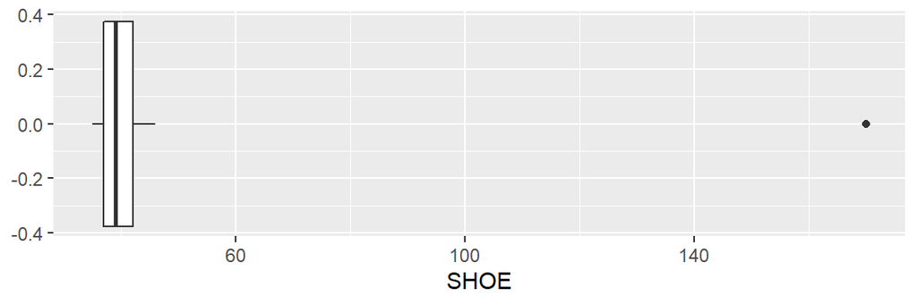

```r
library(ggplot2)
dtf <- read.csv("data/students_env221.csv")
ggplot(dtf) + geom_boxplot(aes(SHOE))
```

```r
dtf <- dtf[dtf$SHOE < 100 & !is.na(dtf$SHOE), ]
mean_shoe <- mean(dtf$SHOE, na.rm = TRUE)
round(mean_shoe, 1)
```

```
[1] 39.5
```

The more information about the students, the more accurate prediction.

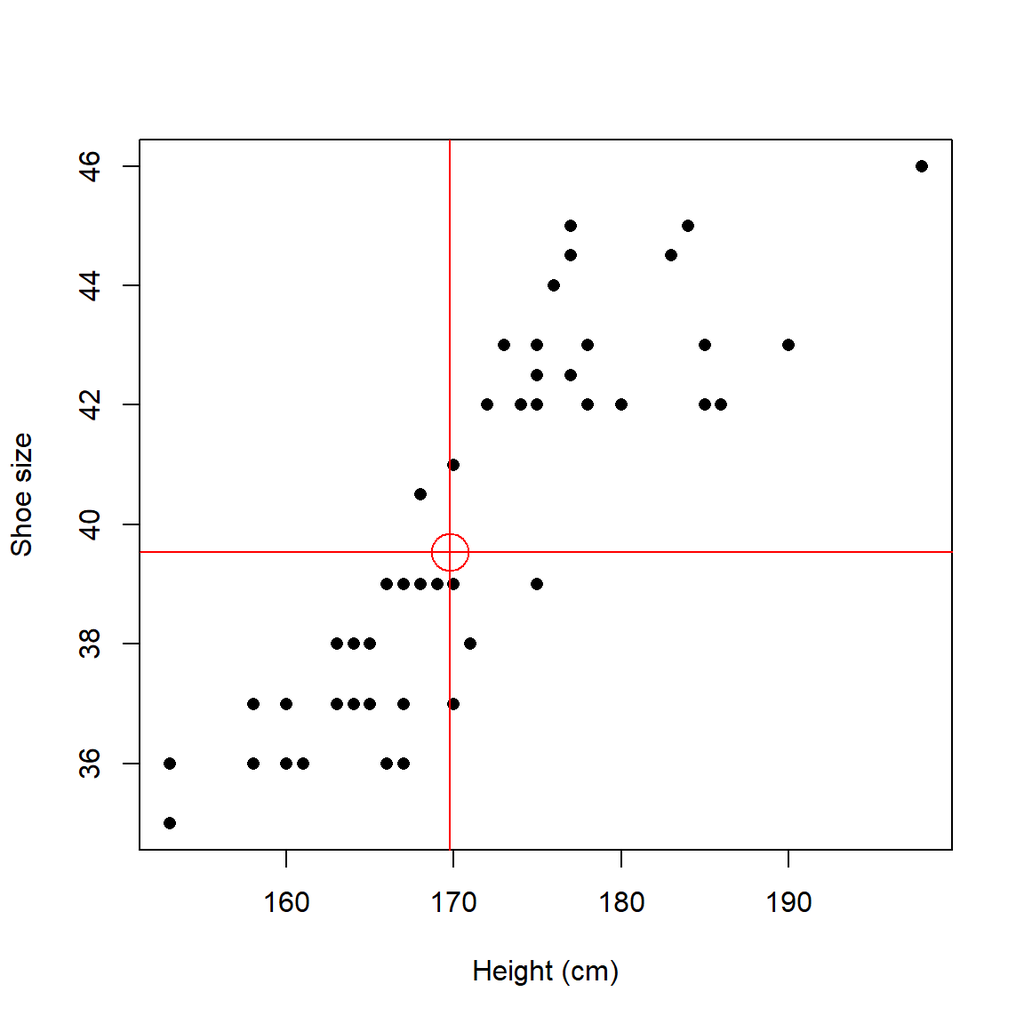

```r
plot(x = dtf$HEIGHT, y = dtf$SHOE, xlab = "Height (cm)", ylab = "Shoe size", pch = 16)
mean_height <- mean(dtf$HEIGHT, na.rm = TRUE)
points(x = mean_height, y = mean_shoe, col = "red", cex = 3)
abline(h = mean_shoe, v = mean_height, col = "red")
```

Generally, a tall student has a large shoe size.

Then, if we know a student’s height, can we predict her/his shoe size better than using the mean?

### 10.2.2 Linear regression

- Draw a line to summarize the relationship in the scatter plot.
- We can draw many many lines. Which one best summarizes the relationship?

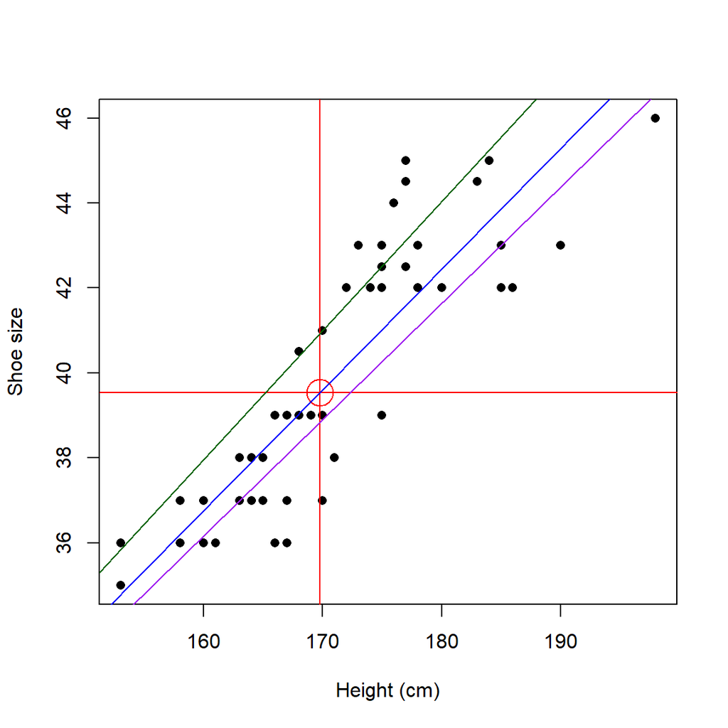

$$y' = a + bx$$

**$a, b$:**

The regression coefficients. $a$ is the intercept, i.e. the point where the line crosses the vertical axis, and $b$ is the slope.

**The regression line (The Least Squares Line):**

The best fitting line, which passes through the maximum number of points and isn’t too far away from the points that it does not pass through.

- The distances in the vertical direction between the points is a minimum — the minimal sum of the square of these distances ($\sum(y'-y)^2$).

$$b = \frac{\sum(x-\bar x)(y -\bar y)}{\sum(x-\bar x)^2}$$

$$a = \bar y - b\bar x$$

Example: Calculate $a$ and $b$ for the regression line of the shoe size against the height, using these two equations above. Give the prediction equation.

```r
mean_height <- mean(dtf$HEIGHT)
b <- sum((dtf$HEIGHT - mean_height) * (dtf$SHOE - mean_shoe)) / sum((dtf$HEIGHT - mean_height) ^ 2)
a <- mean_shoe - b * mean_height
a
```

```
[1] -8.601667
```

```r
b
```

```
[1] 0.2835591
```

$$y' = -8.60 + 0.284 x$$

### 10.2.3 Variation around the regression line

**Residual:**

$y-y'$ (Deviations of the observed $y$-values around the predicted $y$-values)

**Residual variance:**

roughly an average of the squared residuals:

$$s^2_{yx} = \frac{\sum(y-y')^2}{n-2}$$

**Residual standard error:**

$s_{yx} = \sqrt\frac{\sum(y-y')^2}{n-2}$

Example: Fill in the following table. Calculate the residual standard error.

|  | ID | HEIGHT | SHOE | Predicted Shoe (y') | Residual |
| --- | --- | --- | --- | --- | --- |
| 1 | 1 | 169 | 39 |  |  |
| 2 | 2 | 172 | 42 |  |  |
| 3 | 3 | 163 | 38 |  |  |
| 4 | 4 | 170 | 37 |  |  |
| 5 | 5 | 167 | 36 |  |  |
| 6 | 6 | 178 | 43 |  |  |
| 7 | 7 | 158 | 36 |  |  |
| 8 | 8 | 163 | 38 |  |  |
| 9 | 9 | 177 | 45 |  |  |
| 10 | 10 | 186 | 42 |  |  |

[output cut: 45 more lines]

```r
dtf$predicted <- round(a + b * dtf$HEIGHT, 1)
dtf$residual <- round(dtf$SHOE - dtf$predicted, 1)
```

|  | ID | HEIGHT | SHOE | Predicted Shoe (y') | Residual |
| --- | --- | --- | --- | --- | --- |
| 1 | 1 | 169 | 39 | 39.3 | -0.3 |
| 2 | 2 | 172 | 42 | 40.2 | 1.8 |
| 3 | 3 | 163 | 38 | 37.6 | 0.4 |
| 4 | 4 | 170 | 37 | 39.6 | -2.6 |
| 5 | 5 | 167 | 36 | 38.8 | -2.8 |
| 6 | 6 | 178 | 43 | 41.9 | 1.1 |
| 7 | 7 | 158 | 36 | 36.2 | -0.2 |
| 8 | 8 | 163 | 38 | 37.6 | 0.4 |
| 9 | 9 | 177 | 45 | 41.6 | 3.4 |
| 10 | 10 | 186 | 42 | 44.1 | -2.1 |

[output cut: 45 more lines]

Residual standard error:

```r
syx <- sqrt(sum(dtf$residual ^ 2) / (nrow(dtf) - 2))
syx
```

```
[1] 1.470015
```

The smaller the residual standard error is, the better the fit is.

But how small is the best?

### 10.2.4 Simple linear regression model (SLR)

- *X*: the independent variable. Input or cause variables. Synonyms: predictor variable, regressor, controlled variable, manipulated variable, explanatory variable, exposure variable, risk factor, feature and input variable.
- *Y*: the dependent variable. Output or effect variables. Synonyms: Response variable, regressand, measured variable, responding variable, explained variable, outcome variable, experimental variable, and output variable.
- Regressing *Y* on *X*

Assumptions:

1. Values of *X* are “fixed” and non-random.
2. *X* is measured without error.
3. For each value of *X* there is a subpopulation of values of *Y* that are normally distributed.
4. **Assumption of homoskedasticity**: The variances of the sub-populations of *Y* are equal.
5. **Assumption of linearity**: The means of the sub-populations of *Y* all lie on the same straight line $\mu_{y|x} = \alpha + \beta x$
6. The *Y* values are statistically independent.

SLR model:

$$y' = \alpha + \beta x +\epsilon$$

$$\epsilon = y' - (\alpha + \beta x) = y' - \mu_{y|x}$$

**$\epsilon$:**

The error term. The amount by which an observation *y* deviates from the mean of the subpopulation of *Y* values from which it is drawn.

### 10.2.5 Hypothesis test about the fit

Is there relationshipt between $X$ and $Y$?

1. Hypotheses
- $H_0$: There is no relationship between the height and the shoe size.
- $H_1$: There is relationship between the height and the shoe size.
- Question: Reject $H_0$? Given $\alpha$.
2. Collect data.
3. Calculate a test statistic: $F$-test.

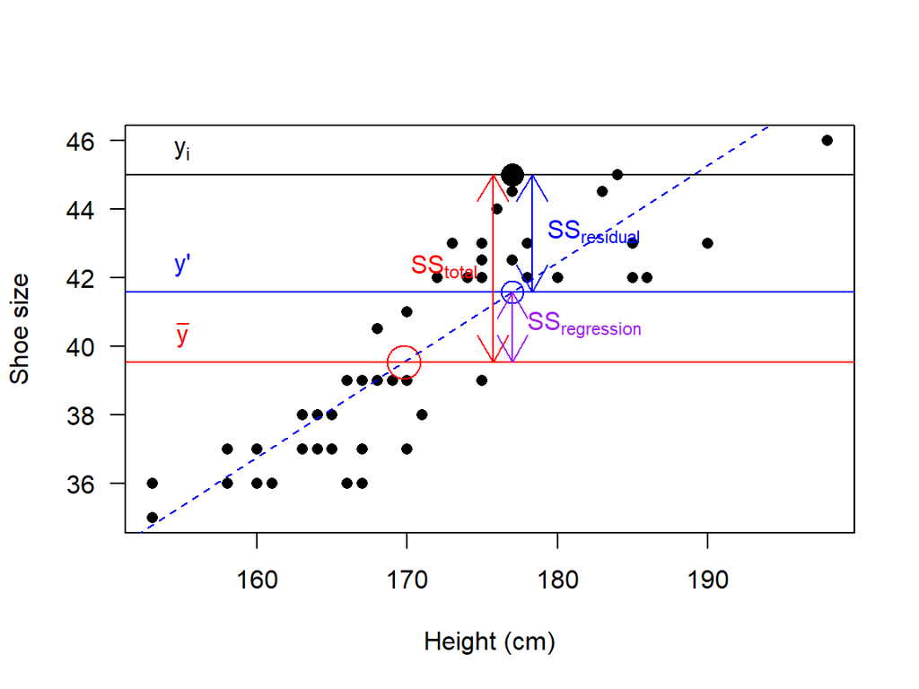

```r
xi <- 177
y_prime <- lm_env$coefficients[1] + lm_env$coefficients[2] * xi
y_mean <- mean_shoe
yi <- dtf$SHOE[dtf$HEIGHT == 177][1]

plot(x = dtf$HEIGHT, y = dtf$SHOE, xlab = "Height (cm)", ylab = "Shoe size", pch = 16, las = 1)
points(x = mean_height, y = mean_shoe, col = "red", cex = 3)
abline(lm_env, col = "blue", lty = 2)
points(x = rep(xi, 2), y = c(y_prime, yi),
       col = c("blue", "black"), pch = c(1, 16), cex = 2)
abline(h = c(y_mean, y_prime, yi), col = c("red", "blue", "black"))
text(x = rep(155, 3), y = c(y_mean, y_prime, yi),
     labels = c(expression(bar(y)), expression("y'"), expression(y[i])),
     pos = 3,
     col = c('red', 'blue', 'black'))
arrows(xi - 1.3, y_mean, xi - 1.3, yi, length = 0.2, code = 3, col = 'red')
text(xi - 1.3, mean(c(y_mean, yi)), expression(SS[total]), pos = 2, col = 'red')
arrows(xi, y_mean, xi, y_prime, length = 0.2, code = 3, col = 'purple')
text(xi, mean(c(y_mean, y_prime)), expression(SS[regression]), pos = 4, col = 'purple')
arrows(xi + 1.3, y_prime, xi + 1.3, yi, length = 0.2, code = 3, col = 'blue')
text(xi + 1.3, mean(c(y_prime, yi)), expression(SS[residual]), pos = 4, col = 'blue')
```

$$y_i - \bar y = (y_i-y') - (y'-\bar y)$$

**$\sum(y_i-y')^2$:**

The residual sum of squares ($SS_\mathrm{residual}$).

**$\sum(y'-\bar y)^2$:**

The regression sum of squares ($SS_\mathrm{regression}$). The gain in prediction due to using the regression line rather than using the mean.

**$\sum(y_i -\bar y)^2$:**

The total sum of squares ($SS_\mathrm{total}$). The numerator of the variance of $y$. The numerator of the total variance.

$$SS_\mathrm{residual} + SS_\mathrm{regression} = SS_\mathrm{total}$$

$$df_\mathrm{residual} + df_\mathrm{regression} = df_\mathrm{total}$$

$$df_\mathrm{regression} = 1$$

$$df_\mathrm{total} = n - 1$$

$$df_\mathrm{residual} = n - 2$$

| Source | $df$ | $SS$ (Sum of squares) | $MS$ (Mean of squares) | $F$ |
| --- | --- | --- | --- | --- |
| between the obs. and the mean | $df_\mathrm{total} = n - 1$ | $SS_\mathrm{total} = \sum(y_i -\bar y)^2$ | $MS_\mathrm{total} = \frac{SS_\mathrm{total}}{df_\mathrm{total}}$ | $F = \frac{MS_\mathrm{regression}}{MS_\mathrm{residual}}$ |
| between the obs. and the regression line | $df_\mathrm{residual} = n - 2$ | $SS_\mathrm{residual} = \sum(y_i-y')^2$ | $MS_\mathrm{residual} = \frac {SS_\mathrm{residual}}{df_\mathrm{residual}}$ |  |
| between the regression line and the mean | $df_\mathrm{regression} = 1$ | $SS_\mathrm{regression} = \sum(y'-\bar y)^2$ | $MS_\mathrm{regression} = \frac{SS_\mathrm{regression}}{df_\mathrm{regression}}$ |  |

- If $H_0$ is true (i.e. no relationship between $x$ and $y$), $MS_\mathrm{regression}$ should be no greater than $MS_\mathrm{residual}$.
- If $H_0$ is false (i.e. relationship between $x$ and $y$), $MS_\mathrm{regression}$ should be greater than $MS_\mathrm{residual}$.

Equivalent hypotheses:

- $H_0: \sigma ^2_\mathrm{regression} \le \sigma ^2_\mathrm{residual}$
- $H_1: \sigma ^2_\mathrm{regression} > \sigma ^2_\mathrm{residual}$
- $F$-test

*Action*: Fill in the following table.

| Source | $df$ | $SS$ | $MS$ | $F$ |
| --- | --- | --- | --- | --- |
| between the obs. and the mean |  |  |  |  |
| between the obs. and the regression line |  |  |  |  |
| between the regression line and the mean |  |  |  |  |

```r
# df
n <- nrow(dtf)
(dftot <- n - 1)
(dfres <- n - 2)
(dfreg <- 1)
dftot - dfres

# SS
(SStot <- sum((dtf$SHOE - mean_shoe) ^ 2))
(SSres <- sum((dtf$SHOE - dtf$predicted) ^2))
(SSreg <- sum((dtf$predicted - mean_shoe) ^ 2))
SSreg + SSres

# MS
(MSreg <- SSreg / dfreg)
(MSres <- SSres / dfres)

# F
(F_score <- MSreg / MSres)
(F_critical <- qf(0.05, df1 = dfreg, df2 = dfres, lower.tail = FALSE))
(p_value <- pf(F_score, df1 = dfreg, df2 = dfres, lower.tail = FALSE))
```

| Source | $df$ | $SS$ | $MS$ | $F$ |
| --- | --- | --- | --- | --- |
| between the obs. and the mean | 54 | 503.4272727 |  |  |
| between the obs. and the regression line | 53 | 114.53 | 2.1609434 |  |
| between the regression line and the mean | 1 | 388.4354545 | 388.4354545 | 179.7527206 |

4. Decision.

With 1 and 53 degrees of freedom and $\alpha = 0.05$, the critical value of $F$ is 4.023017. The calculated $F$ (179.7527206) is greater than the critical $F$, so the decision is to reject $H_0$.

5. Conclusion. There is relationship beteen the body height and the shoe size.

### 10.2.6 Hypothesis test about the slope

Is the population slope ($\beta$ in $\mu_{y|x} = \alpha + \beta x$) a given value (such as 0)?

1. Hypotheses:
- $H_0: \beta = 0$. The slope of the regression line is zero.
- $H_1: \beta \ne 0$. The slope of the regression line is not zero.
2. Collect data
3. Calculate a test statistic. $t$-test.

$$t = \frac{b - \beta}{s_b}$$
$$s_b = \frac{s_{yx}}{s_x \sqrt{n-1}}$$

Example: Calculate the $t$ score for the slope of the Shoe-Height regression line.

```r
syx
(sx <- sd(dtf$HEIGHT))
(sb <- syx/(sx * sqrt(n-1)))
beta <- 0
b
(t_score <- (b-beta) /sb)
(t_critical <- qt(0.975, df = n-2))
pt(t_score, df = n - 2, lower.tail = FALSE) * 2
```

4. Decision.

With 53 degrees of freedom and $\alpha = 0.05$, the critical value of $t$ is 2.005746. The calculated $t$ (13.422428) is greater than the critical $t$, so the decision is to reject $H_0$.

5. Conclusion. The slope of the regression line is not equal to 0.

Compare the p-value with the one in the previous F-test.

### 10.2.7 Hypothesis test about the intercept

Is the population intercept ($\alpha$ in $\mu_{y|x} = \alpha + \beta x$) a given value (such as 0)?

1. Hypotheses:
- $H_0: \alpha = 0$. The intercept of the regression line is zero.
- $H_1: \alpha \ne 0$. The intercept of the regression line is not zero.
2. Collect data
3. Calculate a test statistic. $t$-test.

$$t = \frac{a - \alpha}{s_a}$$
$$s_a = s_{yx}\sqrt{\frac{1}{n} + \frac{\bar x^2}{(n-1)s_x^2}}$$

Example: Calculate the $t$ score for the intercept of the Shoe-Height regression line.

```r
syx
n
(xbar <- mean_height)
sx
(sa <- syx * sqrt(1/n + xbar ^2 / ((n-1) * sx^2)))
alpha <- 0
a
(t_score <- (a-alpha) /sa)
(t_critical <- qt(0.975, df = n-1))
pt(t_score, df = n - 2) * 2
```

4. Decision.

With 54 degrees of freedom and $\alpha = 0.05$, the critical value of $t$ is 2.0048793. The absolute value of the calculated $t$ (-2.394766) is greater than the critical $t$, so the decision is to reject $H_0$.

5. Conclusion: The intercept of the regression line is not equal to 0.

### 10.2.8 One-step in R

```r
env_lm <- lm(SHOE ~ HEIGHT, data = dtf)
env_lm
env_lm$coefficients
summary(env_lm)
```

### 10.2.9 Visualization

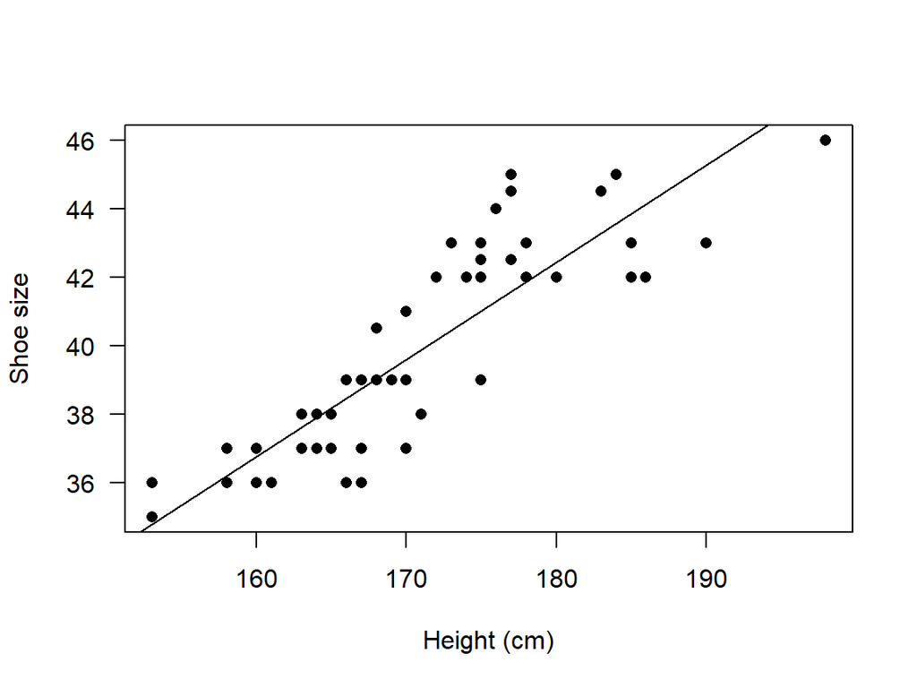

```r
plot(dtf$HEIGHT, dtf$SHOE, xlab = 'Height (cm)', ylab = 'Shoe size', las = 1, pch = 16)
abline(lm_env)
```

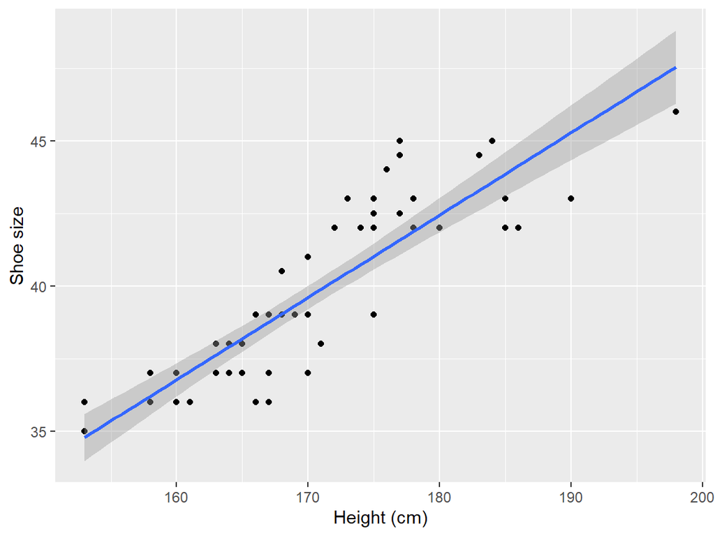

```r
library(ggplot2)
ggplot(dtf, aes(HEIGHT, SHOE)) +
  geom_point() +
  geom_smooth(method = "lm") +
  labs(x = 'Height (cm)', y = 'Shoe size')
```

## 10.3 Correlation

### 10.3.1 Basic Concepts

**Correlation:**

The technique used to assess two variables that have a co-relationship with one another.

**Positive correlation:**

High values on one are associated with high values on the other.

**Negative correlation:**

High values on one are associated with low values on the other.

**Population Correlation Coefficient ($\rho$):**

The parameter which measures the strength of the linear relationship.

- $-1 \le \rho \le +1$.
- $\rho = −1$: perfect negative correlation between the two variables
- $\rho = 1$: perfect positive correlation.
- $\rho = 0$: the two variables are not linearly correlated.

Sample correlation coefficient $r$:

$$r = \frac{\frac{1}{n-1} \sum(x-\bar x)(y - \bar y)}{s_x s_y}$$

or:

$$r = \frac{\mathrm{cov}(x,y)}{s_x s_y}$$

**$\mathrm{cov}(x,y)$:**

covariance, which represents $x$ and $y$ varying together.

Example: Calculate the correlation coefficient for the height and shoe size data using the equations above.

```r
n <- nrow(dtf)
co <- 1 / (n - 1) * sum((dtf$SHOE - mean(dtf$SHOE)) * (dtf$HEIGHT - mean(dtf$HEIGHT)))
cov(dtf$SHOE, dtf$HEIGHT)
sx <- sd(dtf$HEIGHT)
sy <- sd(dtf$SHOE)
r <- co / (sx * sy)

# one step
cor(dtf$HEIGHT, dtf$SHOE)
```

What does it mean?

### 10.3.2 Revisit the regression

| Source | $df$ | $SS$ | $MS$ | $F$ |
| --- | --- | --- | --- | --- |
| between the obs. and the mean | $df_\mathrm{total} = n - 1$ | $SS_\mathrm{total} = \sum(y -\bar y)^2$ | $MS_\mathrm{total} = \frac{SS_\mathrm{total}}{df_\mathrm{total}}$ | $F = \frac{MS_\mathrm{regression}}{MS_\mathrm{residual}}$ |
| between the obs. and the regression line | $df_\mathrm{residual} = n - 2$ | $SS_\mathrm{residual} = \sum(y-y')^2$ | $MS_\mathrm{residual} = \frac {SS_\mathrm{residual}}{df_\mathrm{residual}}$ |  |
| between the regression line and the mean | $df_\mathrm{regression} = 1$ | $SS_\mathrm{regression} = \sum(y'-\bar y)^2$ | $MS_\mathrm{regression} = \frac{SS_\mathrm{regression}}{df_\mathrm{regression}}$ |  |

Alternatively, we compare $SS_\mathrm{regression}$ with $SS_\mathrm{total}$. If the ratio of them is large, it tells us the $x$-$y$ relationship is strong.

Example: Calculate $\frac{SS_\mathrm{regression}}{SS_\mathrm{total}}$. Calculate $r^2$.

```r
dtf$predicted <- a + b * dtf$HEIGHT
SStot <- sum((dtf$SHOE - mean(dtf$SHOE)) ^ 2)
SSres <- sum((dtf$SHOE - dtf$predicted) ^2)
SSreg <- sum((dtf$predicted - mean(dtf$SHOE)) ^ 2)

SSreg / SStot
```

```
[1] 0.7733371
```

```r
r ^ 2
```

```
[1] 0.7733371
```

**$r^2$:**

Coefficient of determination.

$SS_\mathrm{regression}$ explains 77% of $SS_\mathrm{total}$. Is it a large proportion?

| Correlation Coefficient (r) | Description (Rough Guideline ) |
| --- | --- |
| +1.0 | Perfect + association |
| +0.8 to 1.0 | Very strong + association |
| +0.6 to 0.8 | Strong + association |
| +0.4 to 0.6 | Moderate + association |
| +0.2 to 0.4 | Weak + association |
| 0.0 to +0.2 | Very weak + or no association |
| 0.0 to -0.2 | Very weak - or no association |
| -0.2 to – 0.4 | Weak - association |
| -0.4 to -0.6 | Moderate - association |
| -0.6 to -0.8 | Strong - association |
| -0.8 to -1.0 | Very strong - association |
| -1.0 | Perfect negative association |

### 10.3.3 Hypothesis test about correlation

Is the population correlation coefficient $\rho$ equal to a given value (such as zero)?

- Sample statistic: $r$
- Population parameter: $\rho$
1. Hypotheses
- $H_0: \rho = 0$
- $H_1: \rho \ne 0$
- Question: Reject $H_0$? Given $\alpha$.
2. Collect data
3. Calculate a test statistic.

$$t = \frac{r - \rho}{s_r}$$

$$s_r = \sqrt {\frac{1 - r ^2}{n-2}}$$

$$t=r \sqrt{\frac{n-2}{1-r^{2}}}$$

*Action*: Calculate the $t$ score of the hypothesis test about correlation coefficient.

```r
t_score <- r * sqrt((n-2) / (1 - r ^ 2))
t_critical <- qt(0.975, df = n - 2)
pt(t_score, df = n-2, lower.tail = FALSE) * 2
```

4. Decision: reject $H_0$ at $\alpha = 0.05$.
5. Conclusion: The population correlation coefficient is not zero.

### 10.3.4 Fast calculations in R

```r
env_lm <- lm(SHOE ~ HEIGHT, data = dtf)
env_lm
```

```
Call:
lm(formula = SHOE ~ HEIGHT, data = dtf)

Coefficients:
(Intercept)       HEIGHT
    -8.6017       0.2836
```

```r
summary(env_lm)
```

```
Call:
lm(formula = SHOE ~ HEIGHT, data = dtf)

Residuals:
    Min      1Q  Median      3Q     Max
-2.7527 -0.8123 -0.0363  1.0535  3.4117

Coefficients:
            Estimate Std. Error t value Pr(>|t|)
(Intercept) -8.60167    3.58524  -2.399     0.02 *
HEIGHT       0.28356    0.02109  13.447   <2e-16 ***
---
Signif. codes:  0 '***' 0.001 '**' 0.01 '*' 0.05 '.' 0.1 ' ' 1

Residual standard error: 1.467 on 53 degrees of freedom
Multiple R-squared:  0.7733,    Adjusted R-squared:  0.7691
F-statistic: 180.8 on 1 and 53 DF,  p-value: < 2.2e-16
```

Example: Use the iris data. Calculate $r$ between Sepal.Length, Sepal.Width, Petal.Length, and Petal.Width.

```r
i2 <- iris[, -5]
icor <- cor(i2)
library(beginr)
lmdf(i2)
library(psych)
tb_corr <- corr.test(iris[, 1:4])
tb_corr$r
```

### 10.3.5 Visualization

The **corrplot** package:

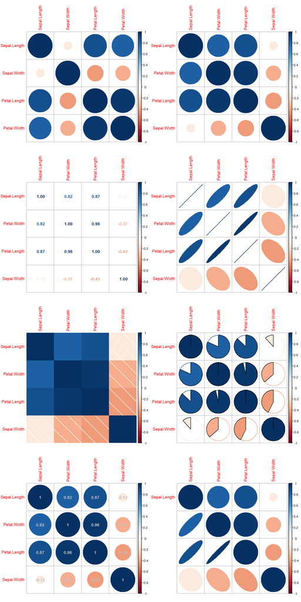

```r
library(corrplot)
par(mfrow = c(4, 2))
corrplot(icor)
corrplot(icor, order = "AOE")
corrplot(icor, order = "AOE", method = "number")
corrplot(icor, order = "AOE", method = "ellipse")
corrplot(icor, order = "AOE", method = "shade")
corrplot(icor, order = "AOE", method = "pie")
corrplot(icor, order = "AOE", addCoef.col = "grey")
corrplot(icor, order = "AOE", type = "upper")
corrplot(icor, order = "AOE", type = "lower", method = "ell",
         diag = FALSE, tl.pos = "n", cl.pos = "n", add = TRUE)
```

The **GGally** package:

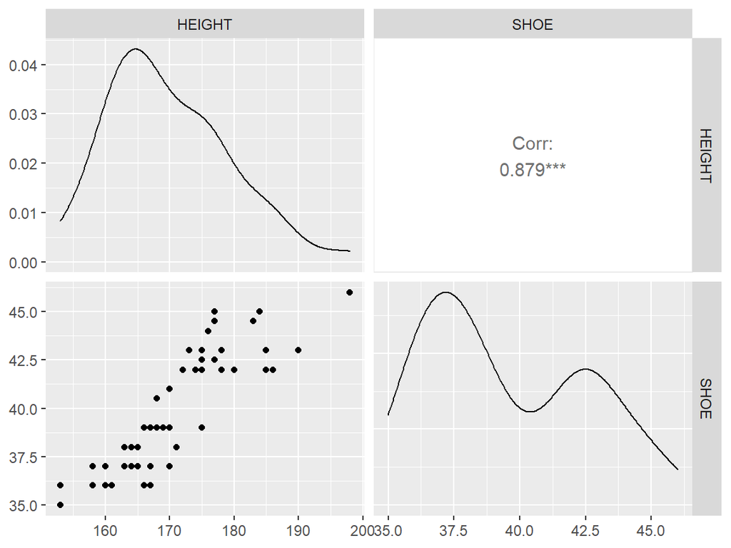

```r
library(GGally)
ggpairs(dtf[, c("HEIGHT", "SHOE")])
```

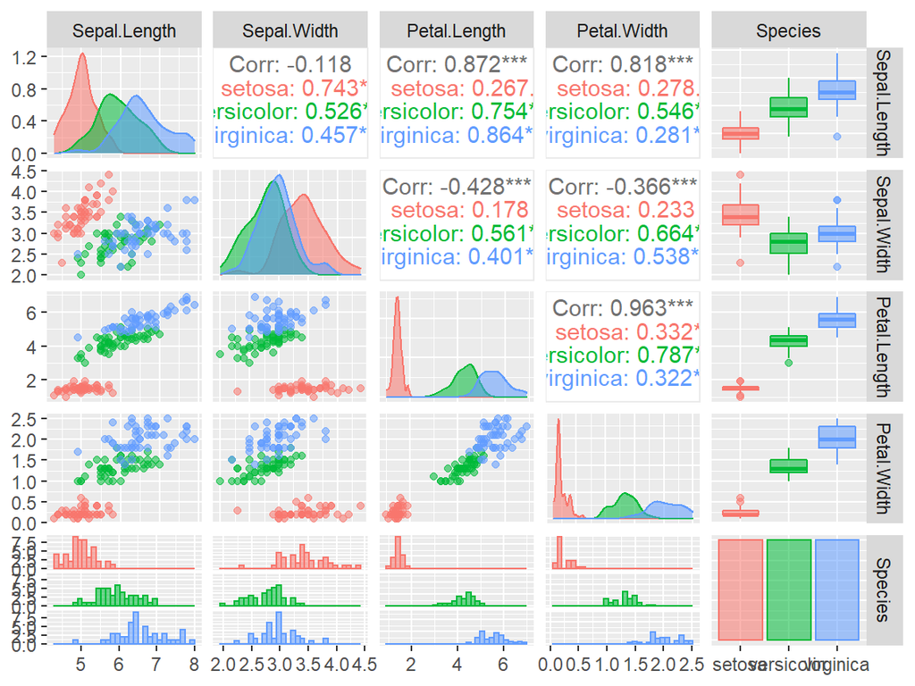

```r
ggpairs(iris, aes(fill = Species, color = Species, alpha = 0.5))
```

## 10.4 Readings

- Applied Environmental Statistics with R - Chapter 11
- Manga Guide to Statistics - Chapter 6

## 10.5 Highlights

- For a scientific question about two numerical variables,
  - Calculate the SLR slope and intercept, and explain them.
  - Calculate the correlation coefficient and the coefficient of determination, and explain them.
  - Carry out hypothesis tests for testing the regression, the slope, the intercept, and the correlation coefficient.
    - State $H_0$ and $H_1$.
    - Calculate the critical value for a given $\alpha$.
    - Calculate the testing statistic.
    - Draw a conclusion.